# ARIMA - U.S. Retail Sales (MRTSSM44000USN)

Claudia Toto

11/17/2026

**Data:** MRTSSM44000USN (FRED / U.S. Census Bureau) — U.S. Retail Sales: Retail Trade, in millions of dollars, monthly and **not seasonally adjusted**, from January 1992 to July 2026 (415 observations).

The analysis has two parts, following the class example:

1. **Non-seasonal ARIMA** using **annual** sales (1992–2025).
2. **Seasonal ARIMA** using **monthly** sales.

```r
library(fpp2)
library(forecast)
library(readxl)
sales <- read_excel("MRTSSM44000USN.xlsx", sheet = "Monthly")
sales_ts <- ts(sales$MRTSSM44000USN, start = c(1992,1), frequency = 12)
# Annual series: sum of the 12 months (2026 is excluded because it only runs through July)
salesannual <- aggregate(window(sales_ts, end = c(2025,12)), FUN = sum)
```

# Part 1: Non-seasonal ARIMA (annual sales)

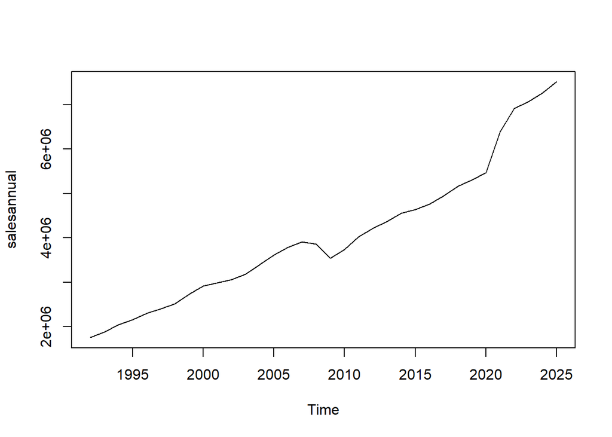

```r
plot(salesannual)
```

**Explanation:** Annual retail sales grow from about $1.76 trillion in 1992 to about $7.52 trillion in 2025, more than a fourfold increase. The series has a **very clear upward trend**, so it is **not stationary** in the mean. There are two visible breaks: the 2008–2009 drop (financial crisis; 2009 was the only year with a sharp decline, ≈ -8.3%) and a strong acceleration after 2020 (post-COVID stimulus and inflation).

```r
ndiffs(salesannual)
```

```
## [1] 1
```

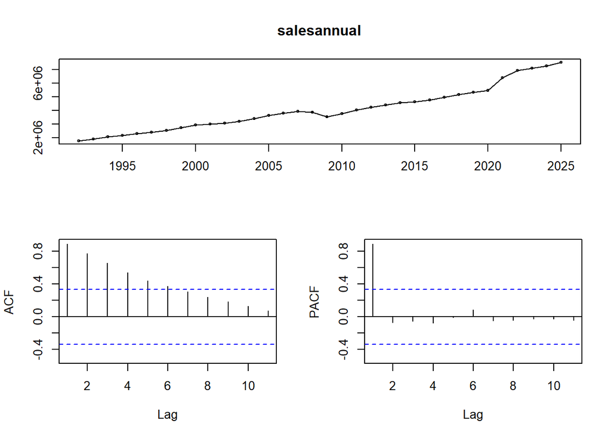

```r
tsdisplay(salesannual)
```

**Explanation:** `ndiffs()` tells us how many differences are needed to make the series stationary (we expect 1 or 2 because of the trend). In `tsdisplay`, the **ACF decays very slowly** (the bars stay high across many lags) and the PACF has a dominant first lag: this is the typical signature of a trending series that needs to be differenced.

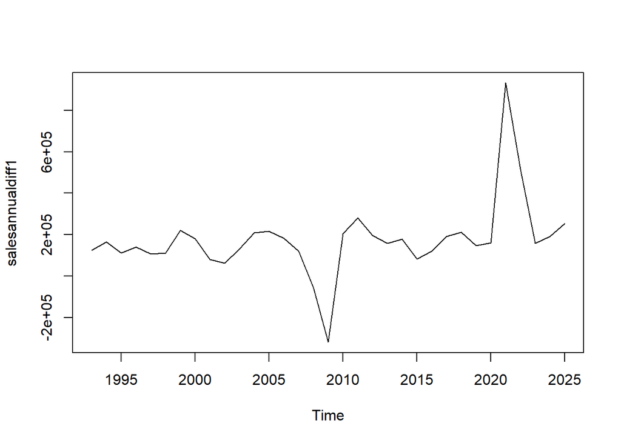

```r
salesannualdiff1 <- diff(salesannual, differences=1)
plot(salesannualdiff1)
```

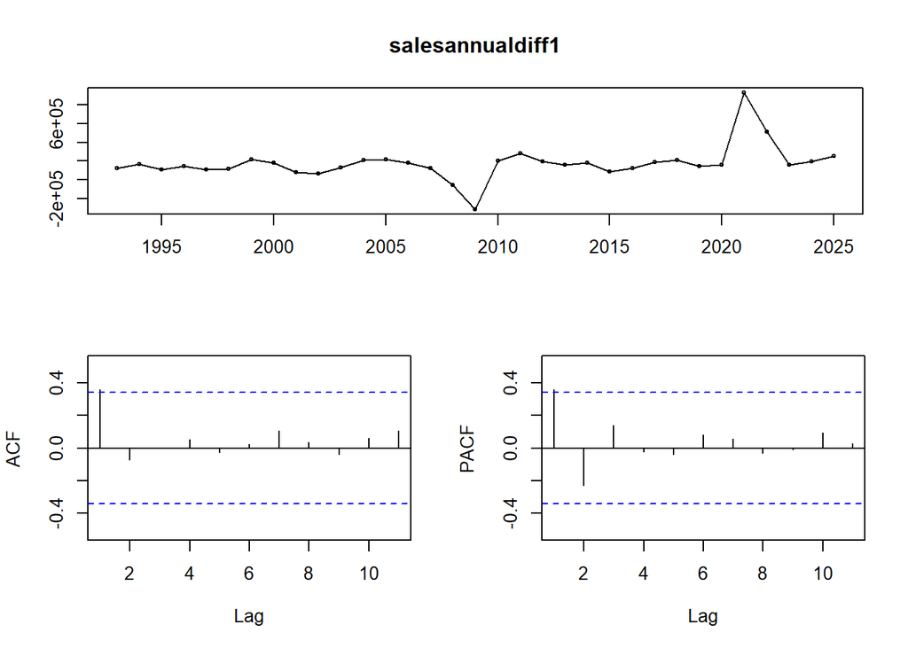

```r
tsdisplay(salesannualdiff1)
```

**Explanation:** The first difference represents **annual growth in dollars** (how much more was sold than the previous year). The trend largely disappears and the series fluctuates around a positive value; the lowest point is 2009 (negative growth) and the highest values appear in 2021–2022. If the ACF/PACF of the differenced series no longer shows significant bars outside the blue lines, one difference is enough.

```r
auto_fit <- auto.arima(salesannual, trace=TRUE, stepwise = FALSE)
```

```
##
##  ARIMA(0,1,0)                    : 916.3268
##  ARIMA(0,1,0) with drift         : 896.7231
##  ARIMA(0,1,1)                    : 903.2192
##  ARIMA(0,1,1) with drift         : 892.6125
##  ARIMA(0,1,2)                    : 903.612
##  ARIMA(0,1,2) with drift         : 895.1649
##  ARIMA(0,1,3)                    : 905.792
##  ARIMA(0,1,3) with drift         : 897.8448
##  ARIMA(0,1,4)                    : Inf
##  ARIMA(0,1,4) with drift         : 900.6797
##  ARIMA(0,1,5)                    : Inf
##  ARIMA(0,1,5) with drift         : Inf
##  ARIMA(1,1,0)                    : 899.8295
##  ARIMA(1,1,0) with drift         : 894.6532
##  ARIMA(1,1,1)                    : 902.2177
##  ARIMA(1,1,1) with drift         : 895.1747
##  ARIMA(1,1,2)                    : Inf
##  ARIMA(1,1,2) with drift         : 897.936
##  ARIMA(1,1,3)                    : Inf
##  ARIMA(1,1,3) with drift         : 900.7579
##  ARIMA(1,1,4)                    : Inf
##  ARIMA(1,1,4) with drift         : Inf
##  ARIMA(2,1,0)                    : 902.2539
##  ARIMA(2,1,0) with drift         : 895.5361
##  ARIMA(2,1,1)                    : Inf
##  ARIMA(2,1,1) with drift         : 897.8453
##  ARIMA(2,1,2)                    : Inf
##  ARIMA(2,1,2) with drift         : Inf
##  ARIMA(2,1,3)                    : Inf
##  ARIMA(2,1,3) with drift         : Inf
##  ARIMA(3,1,0)                    : 901.244
##  ARIMA(3,1,0) with drift         : 897.7146
##  ARIMA(3,1,1)                    : Inf
##  ARIMA(3,1,1) with drift         : 900.7212
##  ARIMA(3,1,2)                    : 904.1958
##  ARIMA(3,1,2) with drift         : Inf
##  ARIMA(4,1,0)                    : 903.5062
##  ARIMA(4,1,0) with drift         : 900.7201
##  ARIMA(4,1,1)                    : 904.2298
##  ARIMA(4,1,1) with drift         : Inf
##  ARIMA(5,1,0)                    : 905.8359
##  ARIMA(5,1,0) with drift         : 903.9225
##
##
##
##  Best model: ARIMA(0,1,1) with drift
```

```r
auto_fit
```

```
## Series: salesannual
## ARIMA(0,1,1) with drift
##
## Coefficients:
##          ma1      drift
##       0.4847  174787.60
## s.e.  0.1536   41571.35
##
## sigma^2 = 2.808e+10:  log likelihood = -442.89
## AIC=891.78   AICc=892.61   BIC=896.27
```

```r
attributes(auto_fit)
```

```
## $names
##  [1] "coef"      "sigma2"    "var.coef"  "mask"      "loglik"    "aic"
##  [7] "arma"      "residuals" "call"      "series"    "code"      "n.cond"
## [13] "nobs"      "model"     "xreg"      "bic"       "aicc"      "x"
## [19] "fitted"
##
## $class
## [1] "fc_model"       "forecast_ARIMA" "ARIMA"          "Arima"
```

**Explanation of the output:** `auto.arima` tests every (p,d,q) combination (`stepwise = FALSE`) and keeps the one with the lowest **AICc**; the `trace` list shows the AICc of each model tested. In the model summary:

- **ARIMA(p,d,q):** p = number of autoregressive (AR) terms (past values), d = number of differences used to remove the trend, q = number of moving-average (MA) terms (past errors).
- **Coefficients (ar/ma/drift):** the estimated weight of each term; a coefficient is significant if it is more than about 2 times its standard error (s.e.). A **drift** term means the model includes an average yearly increase in sales.
- **sigma^2:** the variance of the residuals (the model’s average squared error).
- **log likelihood, AIC, AICc, BIC:** measures of fit; lower AIC/AICc/BIC means a better model, and they are used to compare candidate models.
- `attributes()` lists everything stored in the model object (coef, sigma2, residuals, fitted, etc.), which is why we can use `auto_fit$residuals` and `auto_fit$fitted` later.

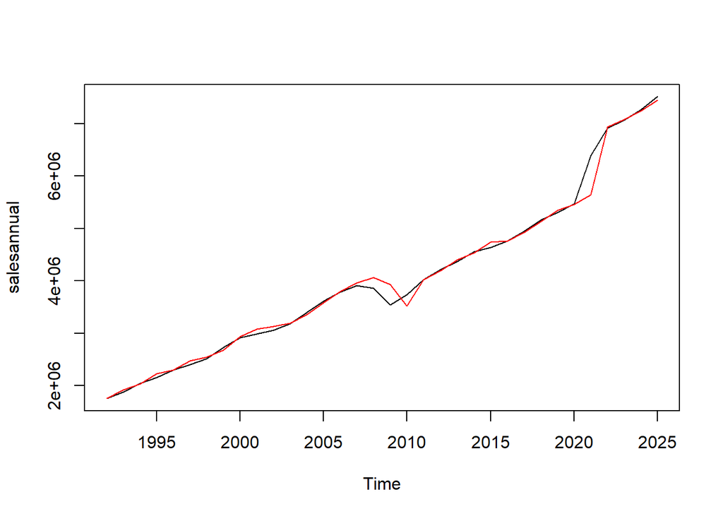

```r
plot(salesannual)
lines(auto_fit$fitted, col = "red")
```

**Explanation:** The **black** line is actual annual sales and the **red** line is the fitted values from the ARIMA model. The closer they are, the better the fit. The red line follows the trend almost perfectly; the most visible errors appear at the turning points (2009 and 2020–2021), because the model cannot anticipate shocks.

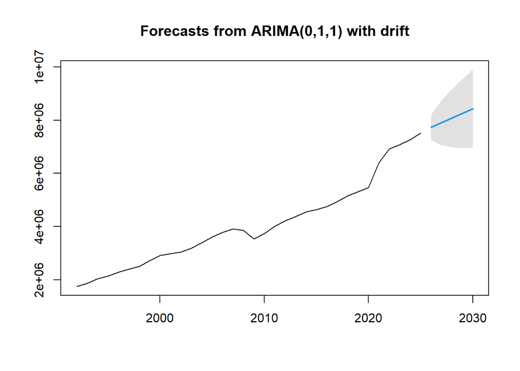

```r
plot(forecast(auto_fit,h=5,level=c(99.5)))
```

**Explanation:** Forecast of annual sales for the next 5 years (2026–2030). The blue line is the point forecast and the shaded band is the **99.5% prediction interval**. The band widens with the horizon: the further out, the greater the uncertainty. The forecast continues the series’ upward trend.

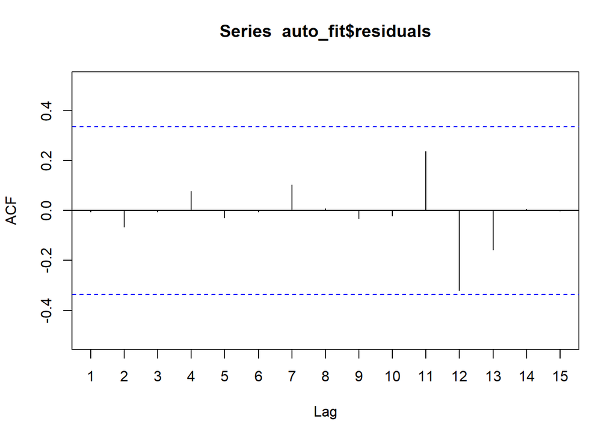

```r
#Residual Analysis
Acf(auto_fit$residuals)
```

```r
Box.test(residuals(auto_fit), lag=20, type="Ljung")
```

```
##
##  Box-Ljung test
##
## data:  residuals(auto_fit)
## X-squared = 11.849, df = 20, p-value = 0.9212
```

**Explanation:** If the model is good, the residuals should be **white noise**. In the ACF, no bars (or almost none) should cross the blue lines. In the **Ljung-Box** test, H0 = the residuals are independent: a **p-value > 0.05** means we fail to reject H0 and the model captured the structure of the data. (With only 34 years, `lag=20` is a high lag; it is kept to follow the class format.)

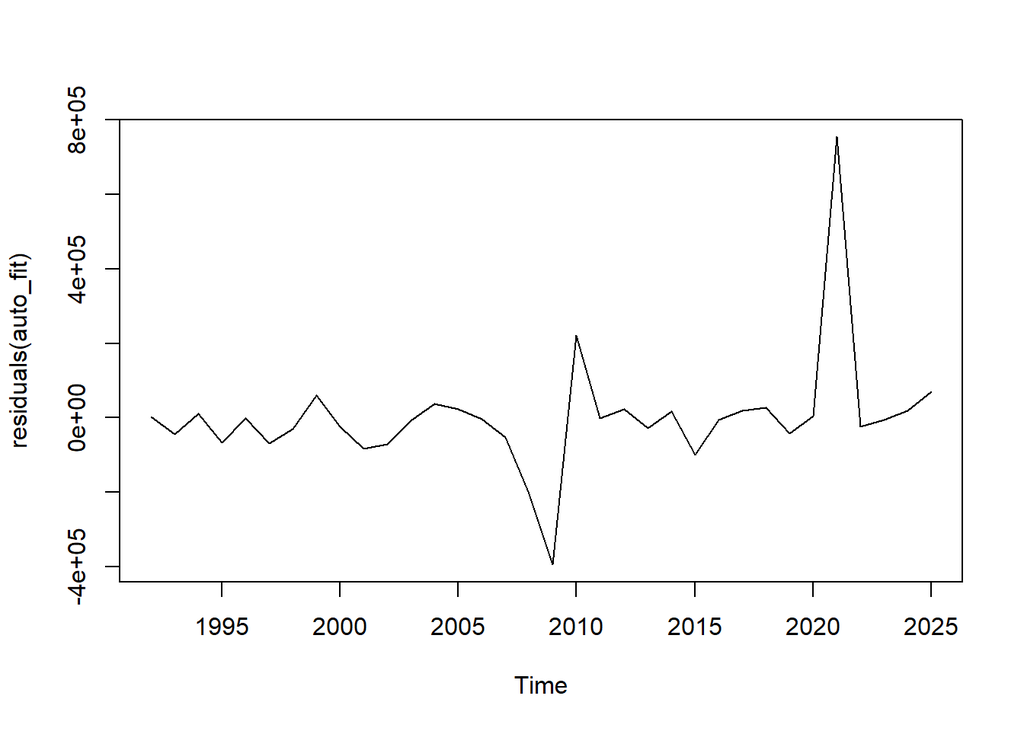

```r
plot.ts(residuals(auto_fit))
```

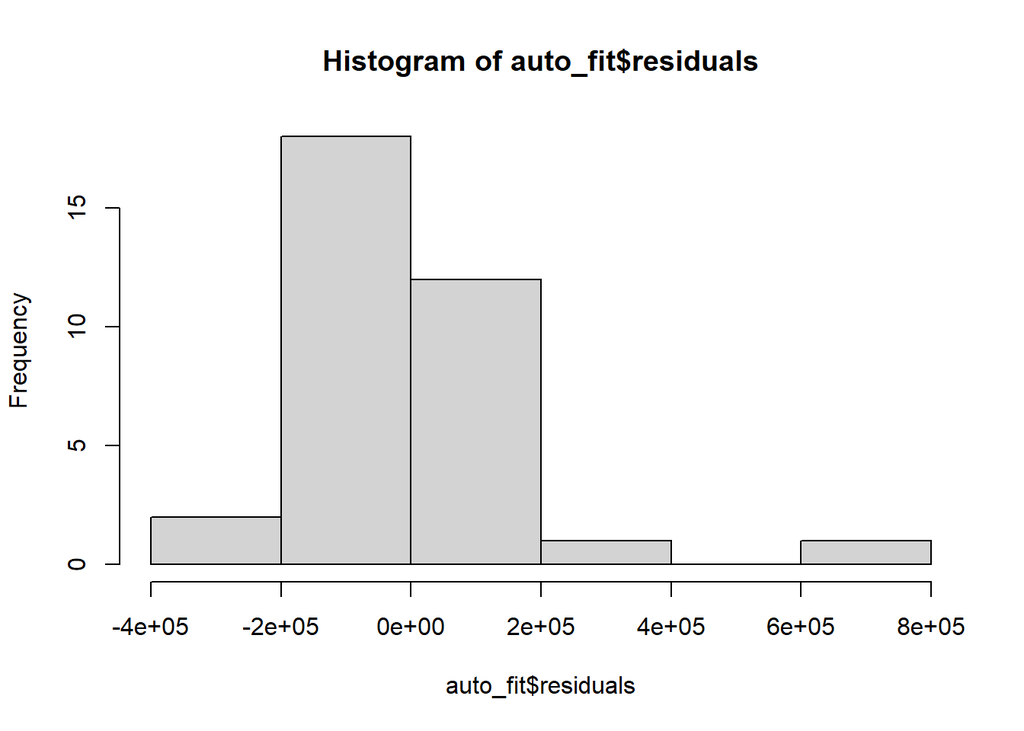

```r
hist(auto_fit$residuals)
```

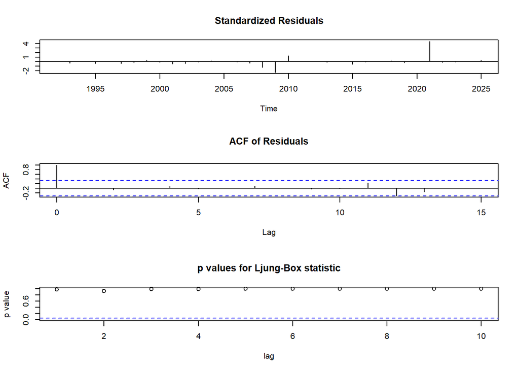

```r
tsdiag(auto_fit)
```

**Explanation:**

- **plot.ts:** the residuals should fluctuate around 0 with no pattern. The largest spikes match 2009 (unexpected drop) and 2021 (post-COVID jump).
- **hist:** ideally bell-shaped and centered at 0 (approximately normal residuals). The unusual years create tails.
- **tsdiag:** shows in one plot (1) the standardized residuals, (2) the ACF of the residuals, and (3) the Ljung-Box p-values for each lag; the points should be **above the dashed 0.05 line**.

```r
#Accuracy
accuracy(auto_fit)
```

```
##                    ME     RMSE      MAE        MPE     MAPE      MASE
## Training set 664.0067 160021.2 75060.54 -0.3732288 1.860554 0.3802904
##                      ACF1
## Training set -0.005317739
```

**Explanation:** `accuracy()` measures the in-sample errors of the annual model:

- **ME (Mean Error):** average error; close to 0 means the model is not biased (it does not systematically over- or under-forecast).
- **RMSE (Root Mean Squared Error):** typical size of the error, in millions of dollars; it penalizes large errors more.
- **MAE (Mean Absolute Error):** average absolute error, in millions of dollars.
- **MPE / MAPE:** the same errors in percent. A **MAPE** below 5% is generally considered a very accurate model.
- **MASE:** compares the model with a naive forecast; a value **below 1** means the ARIMA model beats the naive forecast.
- **ACF1:** autocorrelation of the residuals at lag 1; close to 0 is good.

# Part 2: Seasonal ARIMA (monthly sales)

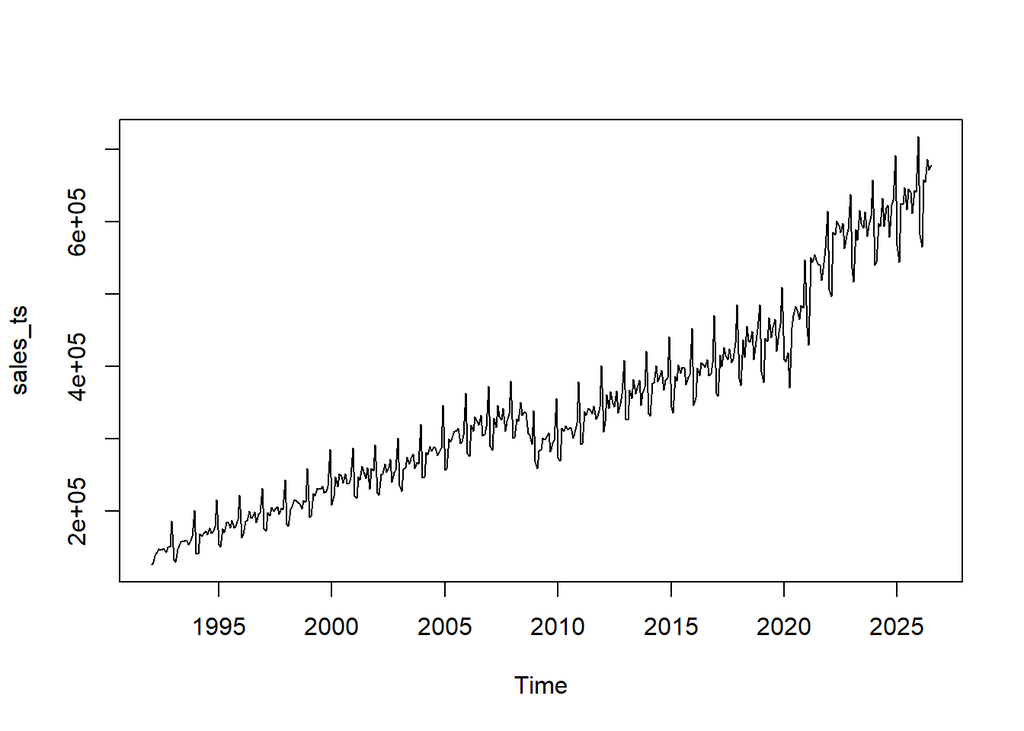

```r
# Seasonal Data
plot(sales_ts)
```

**Explanation:** The monthly series shows two components: an **upward trend** (from ≈ $127 billion in January 1992 to ≈ $677 billion in July 2026) and a **very strong seasonal pattern** that repeats every year. December is always the peak (≈ 15% above the average month, due to the holiday season) and January–February are the lowest months (≈ 11–12% below average). The April 2020 drop is also visible (COVID shutdowns: from $419 billion in March to $371 billion), followed by a quick recovery in May.

```r
nsdiffs(sales_ts)
```

```
## [1] 1
```

```r
ndiffs(sales_ts)
```

```
## [1] 1
```

```r
ndiffs((diff(sales_ts,12)))
```

```
## [1] 1
```

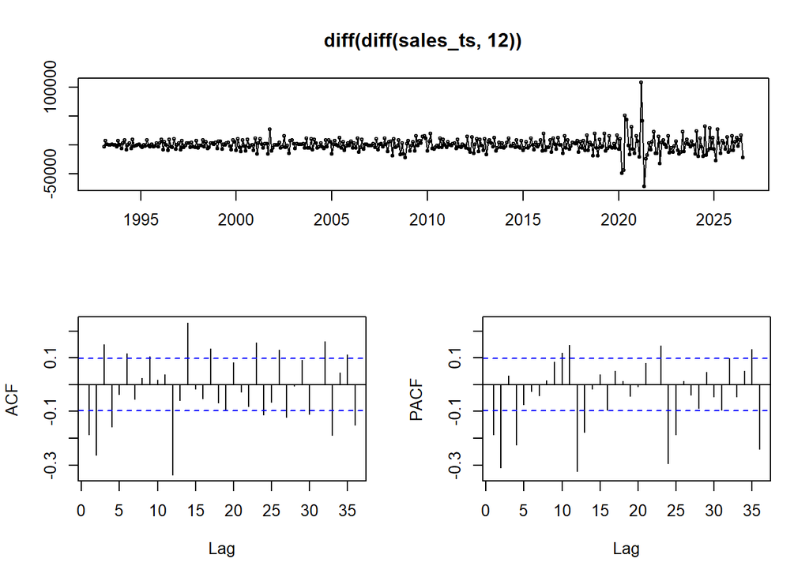

```r
tsdisplay(diff(diff(sales_ts,12)))
```

**Explanation:**

- `nsdiffs()` tells us how many **seasonal differences** (lag 12, because the data are monthly) are needed; we expect 1 given the strong annual pattern.
- `ndiffs()` tells us the regular differences needed for the original series.
- `ndiffs(diff(sales_ts,12))` checks whether, after removing seasonality, a regular difference is still needed to remove the trend.
- `tsdisplay(diff(diff(sales_ts,12)))` shows the series after both a seasonal **and** a regular difference. It should be centered at 0 with no trend. Significant bars in the ACF/PACF at lags 1–3 suggest non-seasonal AR/MA terms, and bars at lags 12, 24, 36 suggest seasonal terms (P, Q). The large spike in 2020 is the COVID shock.

```r
fit3 <- auto.arima(sales_ts,trace=TRUE, stepwise = FALSE )
```

```
##
##  Fitting models using approximations to speed things up...
##
##  ARIMA(0,1,0)(0,1,0)[12]                    : 8479.664
##  ARIMA(0,1,0)(0,1,1)[12]                    : 8355.756
##  ARIMA(0,1,0)(0,1,2)[12]                    : 8353.105
##  ARIMA(0,1,0)(1,1,0)[12]                    : 8442.805
##  ARIMA(0,1,0)(1,1,1)[12]                    : 8363.206
##  ARIMA(0,1,0)(1,1,2)[12]                    : 8363.195
##  ARIMA(0,1,0)(2,1,0)[12]                    : 8422.849
##  ARIMA(0,1,0)(2,1,1)[12]                    : 8361.017
##  ARIMA(0,1,0)(2,1,2)[12]                    : 8336.388
##  ARIMA(0,1,1)(0,1,0)[12]                    : 8450.761
##  ARIMA(0,1,1)(0,1,1)[12]                    : 8301.68
##  ARIMA(0,1,1)(0,1,2)[12]                    : 8303.28
##  ARIMA(0,1,1)(1,1,0)[12]                    : 8397.228
##  ARIMA(0,1,1)(1,1,1)[12]                    : 8312.209
##  ARIMA(0,1,1)(1,1,2)[12]                    : 8313.561
##  ARIMA(0,1,1)(2,1,0)[12]                    : 8367.721
##  ARIMA(0,1,1)(2,1,1)[12]                    : 8313.401
##  ARIMA(0,1,1)(2,1,2)[12]                    : 8297.978
##  ARIMA(0,1,2)(0,1,0)[12]                    : 8420.531
##  ARIMA(0,1,2)(0,1,1)[12]                    : 8292.261
##  ARIMA(0,1,2)(0,1,2)[12]                    : 8290.868
##  ARIMA(0,1,2)(1,1,0)[12]                    : 8384.194
##  ARIMA(0,1,2)(1,1,1)[12]                    : 8301.329
##  ARIMA(0,1,2)(1,1,2)[12]                    : 8301.406
##  ARIMA(0,1,2)(2,1,0)[12]                    : 8360.525
##  ARIMA(0,1,2)(2,1,1)[12]                    : 8300.231
##  ARIMA(0,1,3)(0,1,0)[12]                    : 8417.703
##  ARIMA(0,1,3)(0,1,1)[12]                    : 8283.84
##  ARIMA(0,1,3)(0,1,2)[12]                    : 8283.856
##  ARIMA(0,1,3)(1,1,0)[12]                    : 8374.179
##  ARIMA(0,1,3)(1,1,1)[12]                    : 8294.343
##  ARIMA(0,1,3)(2,1,0)[12]                    : 8350.134
##  ARIMA(0,1,4)(0,1,0)[12]                    : 8414.626
##  ARIMA(0,1,4)(0,1,1)[12]                    : 8278.517
##  ARIMA(0,1,4)(1,1,0)[12]                    : 8367.878
##  ARIMA(0,1,5)(0,1,0)[12]                    : 8415.884
##  ARIMA(1,1,0)(0,1,0)[12]                    : 8468.395
```

[output cut: 51 more lines]

```
##  ARIMA(3,1,1)(0,1,1)[12]                    : 8285.788
##  ARIMA(3,1,1)(1,1,0)[12]                    : 8374.397
##  ARIMA(3,1,2)(0,1,0)[12]                    : 8412.93
##  ARIMA(4,1,0)(0,1,0)[12]                    : 8415.335
##  ARIMA(4,1,0)(0,1,1)[12]                    : 8275.221
##  ARIMA(4,1,0)(1,1,0)[12]                    : 8362.155
##  ARIMA(4,1,1)(0,1,0)[12]                    : 8414.852
##  ARIMA(5,1,0)(0,1,0)[12]                    : 8416.202
##
##  Now re-fitting the best model(s) without approximations...
##
##
##
##
##  Best model: ARIMA(4,1,0)(0,1,1)[12]
```

```r
fit3
```

```
## Series: sales_ts
## ARIMA(4,1,0)(0,1,1)[12]
##
## Coefficients:
##          ar1      ar2      ar3      ar4     sma1
##       -0.321  -0.3470  -0.0174  -0.2162  -0.6891
## s.e.   0.049   0.0514   0.0519   0.0485   0.0347
##
## sigma^2 = 91274357:  log likelihood = -4256.21
## AIC=8524.43   AICc=8524.64   BIC=8548.41
```

**Explanation of the output:** `auto.arima` selected an **ARIMA(4,1,0)(0,1,1)[12]** model (lowest AICc among all the models listed by `trace`):

- **(4,1,0) – non-seasonal part:** d = 1 regular difference removes the trend; p = 4 means each month’s change in sales is explained by the changes of the **previous 4 months** (coefficients ar1–ar4); q = 0, no non-seasonal MA terms.
- **(0,1,1)[12] – seasonal part:** D = 1 seasonal difference (lag 12) removes the yearly pattern, comparing each month with the same month of the previous year; Q = 1 is a **seasonal MA term (sma1)** that corrects the forecast using the error from the same month one year earlier. [12] means the season is 12 months.
- **Coefficients:** each ar and sma value is significant if it is more than about 2 times its standard error (s.e.).
- **sigma^2, log likelihood, AIC, AICc, BIC:** sigma^2 is the residual variance; the information criteria are used to compare models (lower is better).

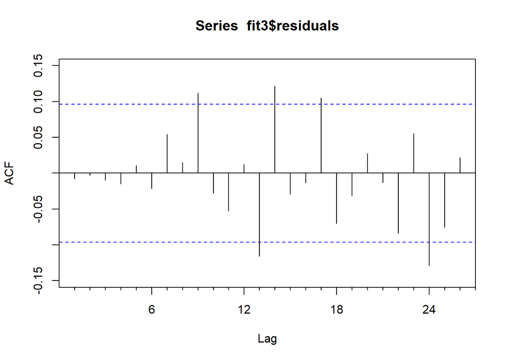

```r
#Residual Analysis
Acf(fit3$residuals)
```

```r
Box.test(residuals(fit3), lag=20, type="Ljung")
```

```
##
##  Box-Ljung test
##
## data:  residuals(fit3)
## X-squared = 28.897, df = 20, p-value = 0.08981
```

**Explanation:** The ACF of the residuals should have no significant bars, especially at the seasonal lags (12 and 24); if it does, the model did not capture all the seasonality. In **Ljung-Box**, a **p-value > 0.05** indicates the residuals behave like white noise. If the p-value is < 0.05, it is usually due to the 2008–2009 and 2020 shocks, which no ARIMA model can predict.

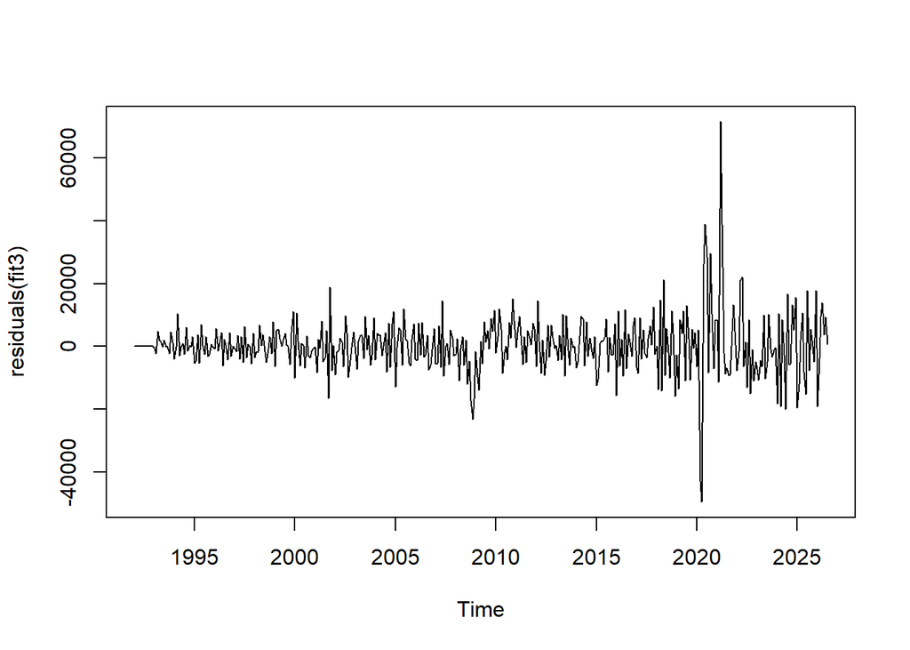

```r
plot.ts(residuals(fit3))
```

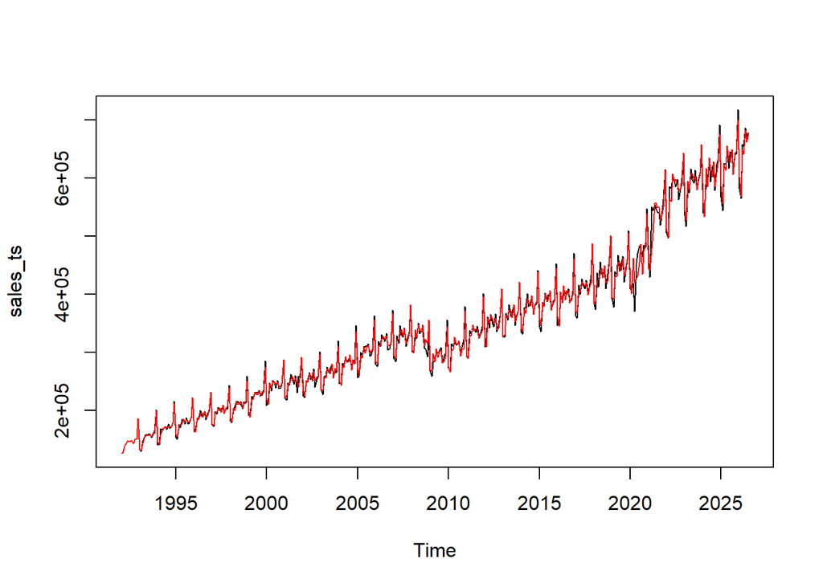

```r
plot(sales_ts)
lines(fit3$fitted, col = "red")
```

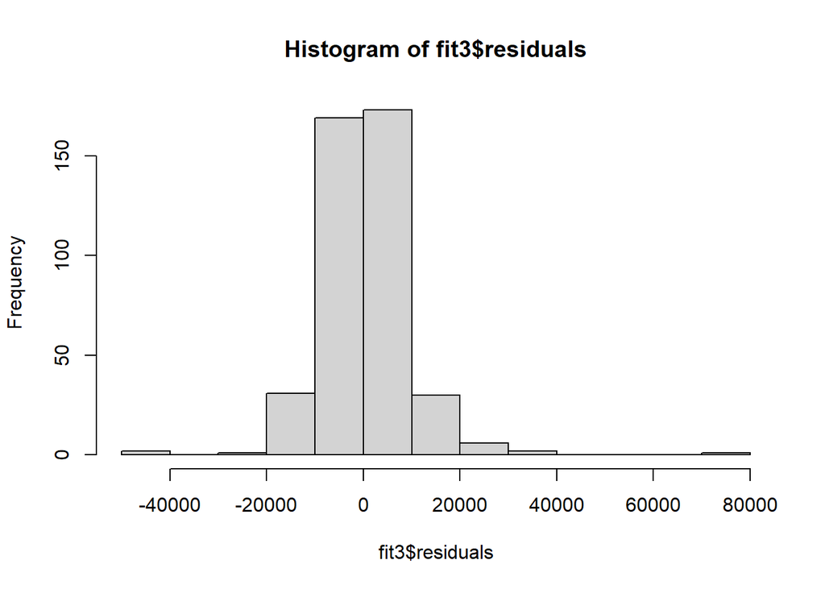

```r
hist(fit3$residuals)
```

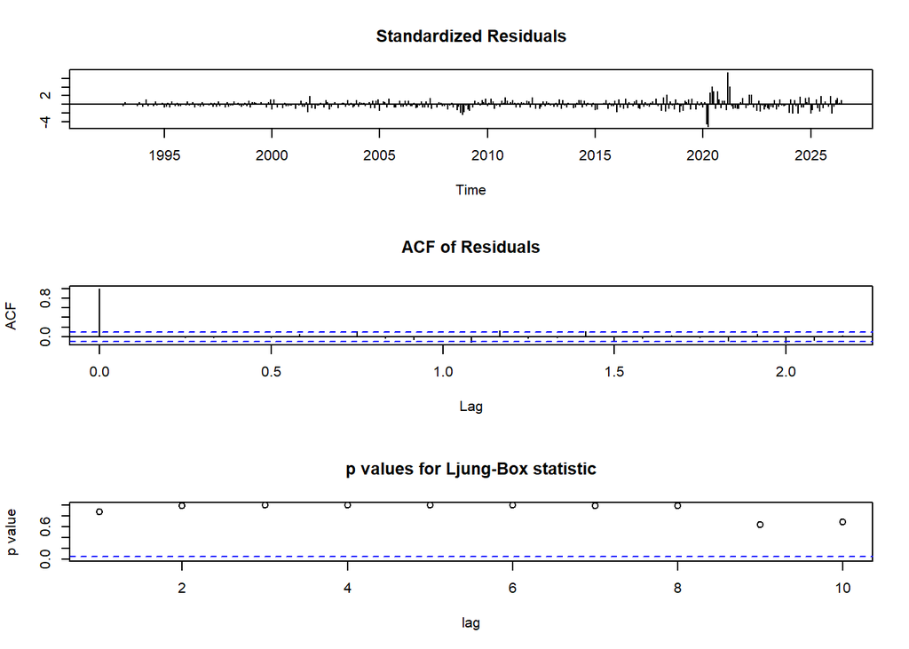

```r
tsdiag(fit3)
```

**Explanation:**

- **hist:** the residuals should be centered at 0 with an approximately bell shape. The left tail reflects the April 2020 drop.
- **tsdiag:** (1) standardized residuals with no pattern, (2) residual ACF within the bands, (3) Ljung-Box p-values by lag above 0.05. If these hold, the seasonal model is adequate for forecasting monthly retail sales.

```r
#Forecast for the next five periods
forecast(fit3,h=5,level=c(99.5))
```

```
##          Point Forecast  Lo 99.5  Hi 99.5
## Aug 2026       680597.0 653779.3 707414.7
## Sep 2026       650751.8 618336.1 683167.6
## Oct 2026       676206.5 641755.0 710658.1
## Nov 2026       684047.1 645939.7 722154.6
## Dec 2026       745821.0 706037.6 785604.4
```

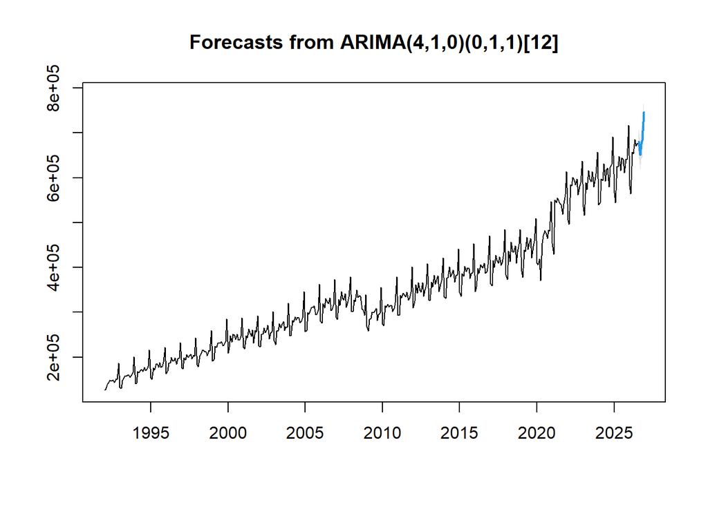

```r
plot(forecast(fit3,h=5,level=c(99.5)))
```

**Explanation:** Forecast of monthly retail sales for the **next five periods (August – December 2026)** with a 99.5% prediction interval. The table shows the point forecast and the lower and upper limits (Lo 99.5 / Hi 99.5) for each month. In the plot, the blue line is the forecast and the gray band is the interval, which widens each month as uncertainty grows. The forecast follows the seasonal pattern: sales stay high through the fall and jump to the **December 2026 peak** (holiday season).

```r
#Accuracy
accuracy(fit3)
```

```
##                   ME     RMSE      MAE       MPE     MAPE      MASE
## Training set 296.845 9344.275 6231.918 0.0121103 1.766956 0.3514805
##                      ACF1
## Training set -0.007778277
```

**Explanation:** In-sample accuracy of the seasonal model. **ME** close to 0 means no systematic bias; **RMSE** and **MAE** give the typical monthly error in millions of dollars; **MAPE** gives the average error in percent (below 5% is considered very accurate); **MASE below 1** means the ARIMA model beats a seasonal naive forecast (using the same month of last year); **ACF1** close to 0 means little autocorrelation is left in the residuals.